# CA4

به نام خدا

هوش مصنوعی

تمرین کامپیوتری شماره 4

علی مهرانی

شماره دانشجویی : 810198542

```python
import pandas as pd
import math
```

# Data analysis

```python
import matplotlib.pyplot as plt
import numpy as np
```

## q1

```python
house_data = pd.read_csv('house_data.csv')
house_data.describe()
```

|  | Unnamed: 0.2 | Unnamed: 0.1 | Unnamed: 0 | id | price | bedrooms | bathrooms | sqft_living | sqft_lot | floors | ... | sqft_above | sqft_basement | yr_built | yr_renovated | zipcode | lat | long | sqft_living15 | sqft_lot15 | house_age |
| --- | --- | --- | --- | --- | --- | --- | --- | --- | --- | --- | --- | --- | --- | --- | --- | --- | --- | --- | --- | --- | --- |
| count | 21613.00000 | 21613.00000 | 21613.00000 | 2.161300e+04 | 2.161300e+04 | 21613.000000 | 21613.000000 | 18528.000000 | 2.161300e+04 | 18530.000000 | ... | 21613.000000 | 21184.000000 | 18531.000000 | 21613.000000 | 21613.000000 | 21613.000000 | 21613.000000 | 21613.000000 | 21613.000000 | 21613.000000 |
| mean | 10806.00000 | 10806.00000 | 10806.00000 | 4.580302e+09 | 5.401822e+05 | 3.367464 | 2.111900 | 2077.569031 | 1.510697e+04 | 1.492903 | ... | 1788.390691 | 292.121082 | 1970.896714 | 84.402258 | 98077.939805 | 47.560053 | -122.213896 | 1986.552492 | 12768.455652 | 50.994864 |
| std | 6239.28002 | 6239.28002 | 6239.28002 | 2.876566e+09 | 3.673622e+05 | 0.943028 | 0.780697 | 953.971679 | 4.142051e+04 | 0.538562 | ... | 828.090978 | 442.637777 | 29.406420 | 401.679240 | 53.505026 | 0.138564 | 0.140828 | 685.391304 | 27304.179631 | 29.373411 |
| min | 0.00000 | 0.00000 | 0.00000 | 1.000102e+06 | 7.500000e+04 | -5.000000 | -5.000000 | -33323.000000 | 5.200000e+02 | 1.000000 | ... | 290.000000 | 0.000000 | 1900.000000 | 0.000000 | 98001.000000 | 47.155900 | -122.519000 | 399.000000 | 651.000000 | 7.000000 |
| 25% | 5403.00000 | 5403.00000 | 5403.00000 | 2.123049e+09 | 3.219500e+05 | 3.000000 | 1.750000 | 1430.000000 | 5.040000e+03 | 1.000000 | ... | 1190.000000 | 0.000000 | 1951.000000 | 0.000000 | 98033.000000 | 47.471000 | -122.328000 | 1490.000000 | 5100.000000 | 25.000000 |
| 50% | 10806.00000 | 10806.00000 | 10806.00000 | 3.904930e+09 | 4.500000e+05 | 3.000000 | 2.250000 | 1920.000000 | 7.618000e+03 | 1.500000 | ... | 1560.000000 | 0.000000 | 1975.000000 | 0.000000 | 98065.000000 | 47.571800 | -122.230000 | 1840.000000 | 7620.000000 | 47.000000 |
| 75% | 16209.00000 | 16209.00000 | 16209.00000 | 7.308900e+09 | 6.450000e+05 | 4.000000 | 2.500000 | 2550.000000 | 1.068800e+04 | 2.000000 | ... | 2210.000000 | 560.000000 | 1996.000000 | 0.000000 | 98118.000000 | 47.678000 | -122.125000 | 2360.000000 | 10083.000000 | 71.000000 |
| max | 21612.00000 | 21612.00000 | 21612.00000 | 9.900000e+09 | 7.700000e+06 | 33.000000 | 8.000000 | 13540.000000 | 1.651359e+06 | 3.500000 | ... | 9410.000000 | 4820.000000 | 2015.000000 | 2015.000000 | 98199.000000 | 47.777600 | -121.315000 | 6210.000000 | 871200.000000 | 122.000000 |

8 rows × 24 columns

## q2

```python
house_data.info()
```

```
<class 'pandas.core.frame.DataFrame'>
RangeIndex: 21613 entries, 0 to 21612
Data columns (total 27 columns):
 #   Column         Non-Null Count  Dtype
---  ------         --------------  -----
 0   Unnamed: 0.2   21613 non-null  int64
 1   Unnamed: 0.1   21613 non-null  int64
 2   Unnamed: 0     21613 non-null  int64
 3   id             21613 non-null  int64
 4   date           21613 non-null  object
 5   price          21613 non-null  float64
 6   bedrooms       21613 non-null  int64
 7   bathrooms      21613 non-null  float64
 8   sqft_living    18528 non-null  float64
 9   sqft_lot       21613 non-null  int64
```

[output cut: 19 more lines]

```python
house_data.isna().sum()
```

```
Unnamed: 0.2        0
Unnamed: 0.1        0
Unnamed: 0          0
id                  0
date                0
price               0
bedrooms            0
bathrooms           0
sqft_living      3085
sqft_lot            0
floors           3083
waterfront          0
view                0
condition           0
grade               0
sqft_above          0
sqft_basement     429
yr_built         3082
yr_renovated        0
zipcode             0
lat                 0
long                0
sqft_living15       0
sqft_lot15          0
location            0
style               0
house_age           0
dtype: int64
```

It can be observed that columns 'sqft_living', 'floors', 'sqft_basement' and 'yr_built' have null values inside them.  
Right now we'll see percentage of null values in each column.  
Each column has total 21613 rows which in some of them there are null values.

```python
for column in house_data:
    print(column, ':', house_data[column].isnull().sum() * 100 / len(house_data), "%")
```

```
Unnamed: 0.2 : 0.0 %
Unnamed: 0.1 : 0.0 %
Unnamed: 0 : 0.0 %
id : 0.0 %
date : 0.0 %
price : 0.0 %
bedrooms : 0.0 %
bathrooms : 0.0 %
sqft_living : 14.273816684402906 %
sqft_lot : 0.0 %
floors : 14.264562994494055 %
waterfront : 0.0 %
view : 0.0 %
condition : 0.0 %
grade : 0.0 %
sqft_above : 0.0 %
sqft_basement : 1.9849164854485726 %
yr_built : 14.259936149539628 %
yr_renovated : 0.0 %
zipcode : 0.0 %
lat : 0.0 %
long : 0.0 %
sqft_living15 : 0.0 %
sqft_lot15 : 0.0 %
location : 0.0 %
style : 0.0 %
house_age : 0.0 %
```

## q3

```python
correlation = house_data.corr().sort_values(by="price", ascending = False)
correlation
```

|  | Unnamed: 0.2 | Unnamed: 0.1 | Unnamed: 0 | id | price | bedrooms | bathrooms | sqft_living | sqft_lot | floors | ... | sqft_above | sqft_basement | yr_built | yr_renovated | zipcode | lat | long | sqft_living15 | sqft_lot15 | house_age |
| --- | --- | --- | --- | --- | --- | --- | --- | --- | --- | --- | --- | --- | --- | --- | --- | --- | --- | --- | --- | --- | --- |
| price | 0.027344 | 0.027344 | 0.027344 | -0.016797 | 1.000000 | 0.304521 | 0.517952 | 0.676542 | 0.089655 | 0.258603 | ... | 0.605566 | 0.321825 | 0.054118 | 0.126442 | -0.053168 | 0.306919 | 0.021571 | 0.585374 | 0.082456 | -0.053982 |
| sqft_living | 0.035777 | 0.035777 | 0.035777 | -0.015295 | 0.676542 | 0.544233 | 0.716446 | 1.000000 | 0.161504 | 0.339825 | ... | 0.841336 | 0.414075 | 0.306722 | 0.056563 | -0.189195 | 0.050515 | 0.223845 | 0.728217 | 0.173270 | -0.306823 |
| sqft_above | 0.071958 | 0.071958 | 0.071958 | -0.010842 | 0.605566 | 0.471557 | 0.676170 | 0.841336 | 0.183512 | 0.528895 | ... | 1.000000 | -0.052071 | 0.424794 | 0.023285 | -0.261190 | -0.000816 | 0.343803 | 0.731870 | 0.194050 | -0.423898 |
| sqft_living15 | 0.026647 | 0.026647 | 0.026647 | -0.002901 | 0.585374 | 0.387249 | 0.561377 | 0.728217 | 0.144608 | 0.284947 | ... | 0.731870 | 0.198724 | 0.327411 | -0.002673 | -0.279033 | 0.048858 | 0.334605 | 1.000000 | 0.183192 | -0.326229 |
| bathrooms | 0.105578 | 0.105578 | 0.105578 | 0.005412 | 0.517952 | 0.502967 | 1.000000 | 0.716446 | 0.087369 | 0.492847 | ... | 0.676170 | 0.279105 | 0.495330 | 0.050823 | -0.200932 | 0.024103 | 0.221867 | 0.561377 | 0.086962 | -0.497137 |
| view | -0.013751 | -0.013751 | -0.013751 | 0.011592 | 0.397346 | 0.079533 | 0.185163 | 0.274517 | 0.074710 | 0.032955 | ... | 0.167649 | 0.274374 | -0.052584 | 0.103917 | 0.084827 | 0.006157 | -0.078400 | 0.280439 | 0.072575 | 0.053440 |
| grade | 0.057077 | 0.057077 | 0.057077 | 0.006461 | 0.389227 | 0.206764 | 0.385041 | 0.403819 | 0.067400 | 0.459559 | ... | 0.440825 | 0.088845 | 0.252567 | 0.009544 | -0.110630 | 0.066462 | 0.118880 | 0.414021 | 0.070974 | -0.264498 |
| sqft_basement | -0.042763 | -0.042763 | -0.042763 | -0.004581 | 0.321825 | 0.300329 | 0.279105 | 0.414075 | 0.016101 | -0.246770 | ... | -0.052071 | 1.000000 | -0.133636 | 0.073309 | 0.074454 | 0.109317 | -0.143841 | 0.198724 | 0.017263 | 0.132770 |
| lat | 0.000701 | 0.000701 | 0.000701 | -0.001891 | 0.306919 | -0.009136 | 0.024103 | 0.050515 | -0.085683 | 0.047007 | ... | -0.000816 | 0.109317 | -0.151130 | 0.029398 | 0.267048 | 1.000000 | -0.135512 | 0.048858 | -0.086419 | 0.148122 |
| bedrooms | 0.011401 | 0.011401 | 0.011401 | 0.002439 | 0.304521 | 1.000000 | 0.502967 | 0.544233 | 0.032014 | 0.179198 | ... | 0.471557 | 0.300329 | 0.155912 | 0.017391 | -0.151093 | -0.009136 | 0.128474 | 0.387249 | 0.029619 | -0.152593 |
| waterfront | -0.007611 | -0.007611 | -0.007611 | -0.002721 | 0.266331 | -0.006180 | 0.063203 | 0.102671 | 0.021604 | 0.022338 | ... | 0.072075 | 0.078302 | -0.024819 | 0.092885 | 0.030285 | -0.014274 | -0.041910 | 0.086463 | 0.030703 | 0.026161 |
| floors | 0.178879 | 0.178879 | 0.178879 | 0.018266 | 0.258603 | 0.179198 | 0.492847 | 0.339825 | -0.001111 | 1.000000 | ... | 0.528895 | -0.246770 | 0.487584 | 0.006620 | -0.062706 | 0.047007 | 0.129144 | 0.284947 | -0.006949 | -0.488574 |
| yr_renovated | -0.025601 | -0.025601 | -0.025601 | -0.016907 | 0.126442 | 0.017391 | 0.050823 | 0.056563 | 0.007644 | 0.006620 | ... | 0.023285 | 0.073309 | -0.226692 | 1.000000 | 0.064357 | 0.029398 | -0.068372 | -0.002673 | 0.007854 | 0.224874 |
| sqft_lot | -0.026877 | -0.026877 | -0.026877 | -0.132109 | 0.089655 | 0.032014 | 0.087369 | 0.161504 | 1.000000 | -0.001111 | ... | 0.183512 | 0.016101 | 0.052470 | 0.007644 | -0.129574 | -0.085683 | 0.229521 | 0.144608 | 0.718557 | -0.053080 |
| sqft_lot15 | -0.029827 | -0.029827 | -0.029827 | -0.138798 | 0.082456 | 0.029619 | 0.086962 | 0.173270 | 0.718557 | -0.006949 | ... | 0.194050 | 0.017263 | 0.070863 | 0.007854 | -0.147221 | -0.086419 | 0.254451 | 0.183192 | 1.000000 | -0.070958 |
| yr_built | 0.200354 | 0.200354 | 0.200354 | 0.022445 | 0.054118 | 0.155912 | 0.495330 | 0.306722 | 0.052470 | 0.487584 | ... | 0.424794 | -0.133636 | 1.000000 | -0.226692 | -0.349254 | -0.151130 | 0.409370 | 0.327411 | 0.070863 | -1.000000 |
| condition | -0.095419 | -0.095419 | -0.095419 | -0.023783 | 0.036392 | 0.028977 | -0.122359 | -0.061605 | -0.008958 | -0.265661 | ... | -0.158214 | 0.173568 | -0.362782 | -0.060618 | 0.003026 | -0.014941 | -0.106500 | -0.092824 | -0.003406 | 0.361417 |
| Unnamed: 0.2 | 1.000000 | 1.000000 | 1.000000 | 0.006718 | 0.027344 | 0.011401 | 0.105578 | 0.035777 | -0.026877 | 0.178879 | ... | 0.071958 | -0.042763 | 0.200354 | -0.025601 | -0.002199 | 0.000701 | 0.008649 | 0.026647 | -0.029827 | -0.199549 |
| Unnamed: 0.1 | 1.000000 | 1.000000 | 1.000000 | 0.006718 | 0.027344 | 0.011401 | 0.105578 | 0.035777 | -0.026877 | 0.178879 | ... | 0.071958 | -0.042763 | 0.200354 | -0.025601 | -0.002199 | 0.000701 | 0.008649 | 0.026647 | -0.029827 | -0.199549 |
| Unnamed: 0 | 1.000000 | 1.000000 | 1.000000 | 0.006718 | 0.027344 | 0.011401 | 0.105578 | 0.035777 | -0.026877 | 0.178879 | ... | 0.071958 | -0.042763 | 0.200354 | -0.025601 | -0.002199 | 0.000701 | 0.008649 | 0.026647 | -0.029827 | -0.199549 |
| long | 0.008649 | 0.008649 | 0.008649 | 0.020799 | 0.021571 | 0.128474 | 0.221867 | 0.223845 | 0.229521 | 0.129144 | ... | 0.343803 | -0.143841 | 0.409370 | -0.068372 | -0.564072 | -0.135512 | 1.000000 | 0.334605 | 0.254451 | -0.409356 |
| id | 0.006718 | 0.006718 | 0.006718 | 1.000000 | -0.016797 | 0.002439 | 0.005412 | -0.015295 | -0.132109 | 0.018266 | ... | -0.010842 | -0.004581 | 0.022445 | -0.016907 | -0.008224 | -0.001891 | 0.020799 | -0.002901 | -0.138798 | -0.021380 |
| zipcode | -0.002199 | -0.002199 | -0.002199 | -0.008224 | -0.053168 | -0.151093 | -0.200932 | -0.189195 | -0.129574 | -0.062706 | ... | -0.261190 | 0.074454 | -0.349254 | 0.064357 | 1.000000 | 0.267048 | -0.564072 | -0.279033 | -0.147221 | 0.346869 |
| house_age | -0.199549 | -0.199549 | -0.199549 | -0.021380 | -0.053982 | -0.152593 | -0.497137 | -0.306823 | -0.053080 | -0.488574 | ... | -0.423898 | 0.132770 | -1.000000 | 0.224874 | 0.346869 | 0.148122 | -0.409356 | -0.326229 | -0.070958 | 1.000000 |

24 rows × 24 columns

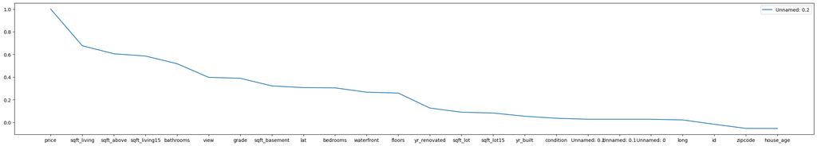

```python
corr_price = correlation.loc[:,"price"]

plt.figure(figsize=(30,5))
plt.plot(corr_price)
plt.legend(house_data.columns)
```

It can be observed that 'sqft_living', 'sqft_above' and 'sqft_living_15' have highest dependency to our goal column.

We can also plot the corellation matrix of our dataframe as an alternative approach.

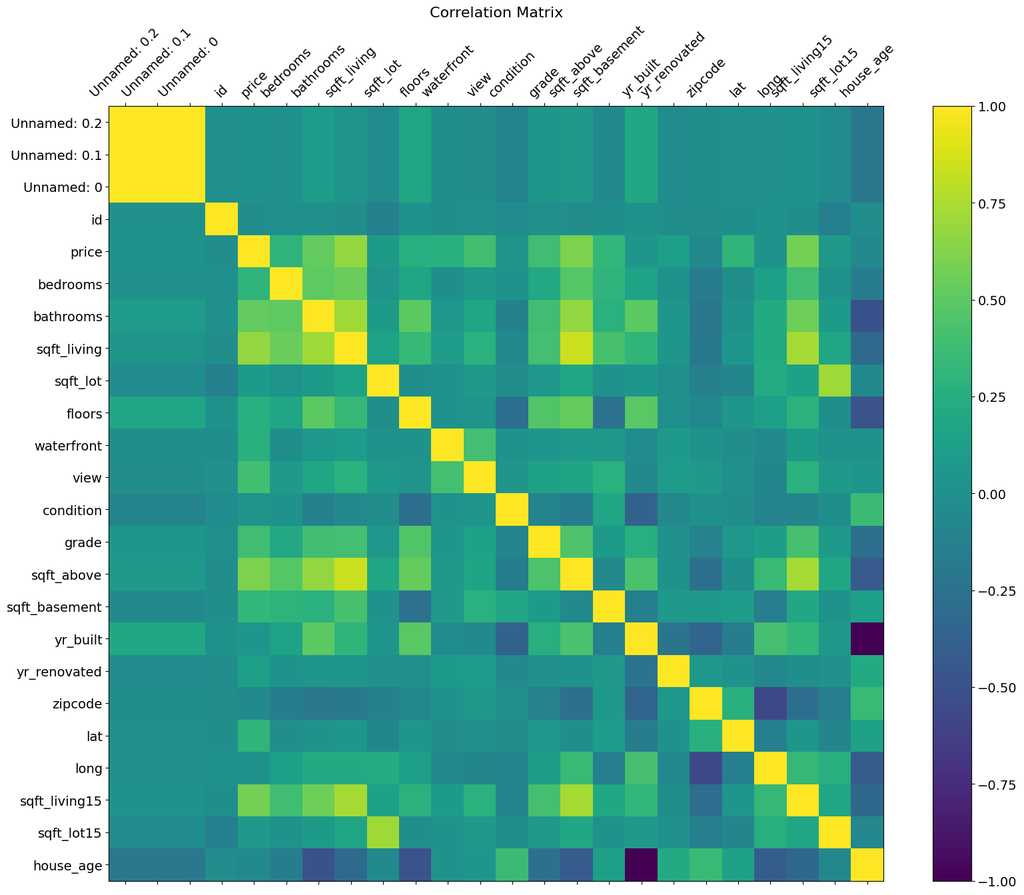

```python
f = plt.figure(figsize=(19, 15))
plt.matshow(house_data.corr(), fignum=f.number)
plt.xticks(range(house_data.select_dtypes(['number']).shape[1]), house_data.select_dtypes(['number']).columns, fontsize=14, rotation=45)
plt.yticks(range(house_data.select_dtypes(['number']).shape[1]), house_data.select_dtypes(['number']).columns, fontsize=14)
cb = plt.colorbar()
cb.ax.tick_params(labelsize=14)
plt.title('Correlation Matrix', fontsize=16);
```

considering 'price' as our goal column, it can be observed that 'sqft_living', 'sqft_above' and 'sqft_living_15' have more correlation to our goal column.

## q4

### sqft_living

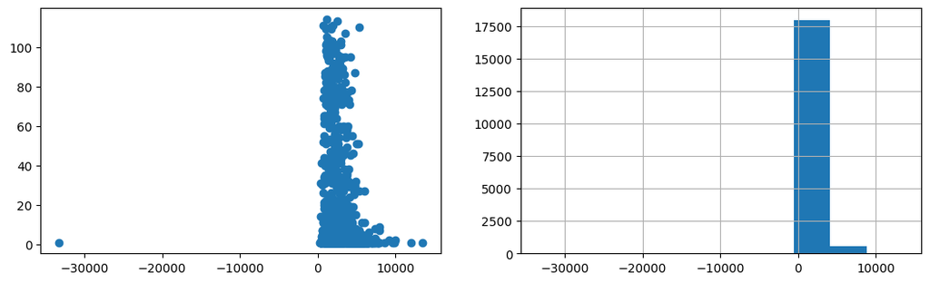

```python
x_value_sqft_living = house_data['sqft_living'].unique()
x_value_sqft_living = x_value_sqft_living[~np.isnan(x_value_sqft_living)]
y_value_sqft_living = house_data['sqft_living'].value_counts()

plt.figure(figsize = (20, 8))
plt.subplot(2,3,1)
plt.scatter(x=x_value_sqft_living, y=y_value_sqft_living)
plt.subplot(2,3,2)
house_data['sqft_living'].hist()

plt.show()
```

### sqft_above

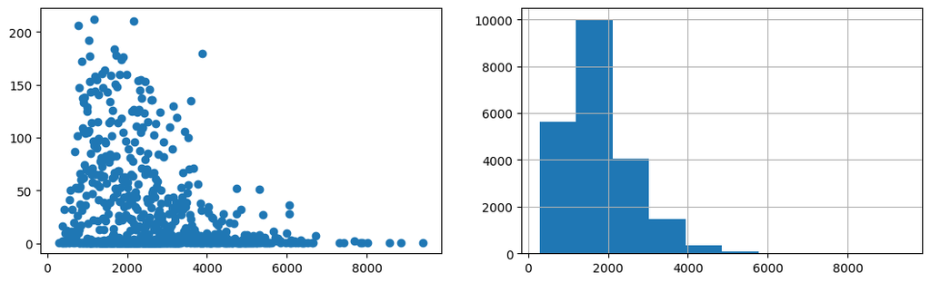

```python
x_value_sqft_above = house_data['sqft_above'].unique()
x_value_sqft_above = x_value_sqft_above[~np.isnan(x_value_sqft_above)]
y_value_sqft_above = house_data['sqft_above'].value_counts()

plt.figure(figsize = (20, 8))
plt.subplot(2,3,1)
plt.scatter(x=x_value_sqft_above, y=y_value_sqft_above)
plt.subplot(2,3,2)
house_data['sqft_above'].hist()
```

### sqft_living_15

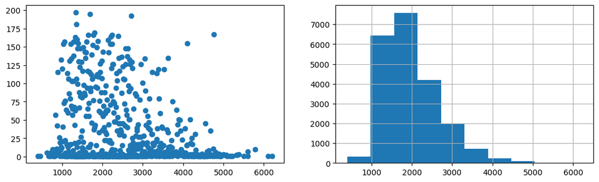

```python
x_value_sqft_living15 = house_data['sqft_living15'].unique()
x_value_sqft_living15 = x_value_sqft_living15[~np.isnan(x_value_sqft_living15)]
y_value_sqft_living15 = house_data['sqft_living15'].value_counts()

plt.figure(figsize = (20, 8))
plt.subplot(2,3,1)
plt.scatter(x=x_value_sqft_living15, y=y_value_sqft_living15)
plt.subplot(2,3,2)
house_data['sqft_living15'].hist()
```

## q5

### sqft_living

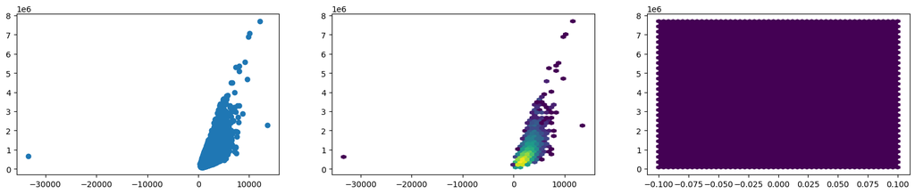

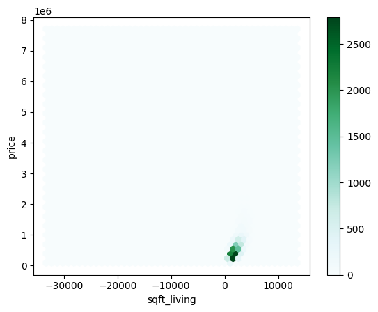

```python
plt.figure(figsize = (20, 8))

plt.subplot(2,3,1)
plt.scatter(x=house_data['sqft_living'], y=house_data['price'])
plt.subplot(2,3,2)
plt.hexbin(x=house_data['sqft_living'], y=house_data['price'], gridsize=50, bins='log')
plt.subplot(2,3,3)
plt.hexbin(x=[house_data['sqft_living']], y=house_data['price'], gridsize=50, bins='log')

house_data.plot.hexbin(x='sqft_living', y='price', gridsize=45)
```

### sqft_above

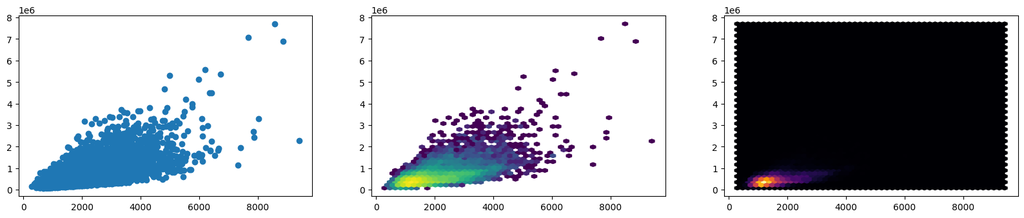

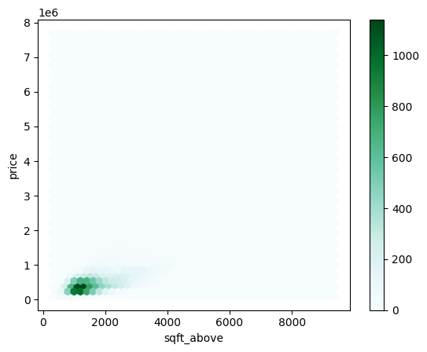

```python
plt.figure(figsize = (20, 8))

plt.subplot(2,3,1)
plt.scatter(x=house_data['sqft_above'], y=house_data['price'])
plt.subplot(2,3,2)
plt.hexbin(x=house_data['sqft_above'], y=house_data['price'], gridsize=50, bins='log')
plt.subplot(2,3,3)
plt.hexbin(x=[house_data['sqft_above']], y=house_data['price'], gridsize=50, cmap='inferno')

house_data.plot.hexbin(x='sqft_above', y='price', gridsize=45)
```

### sqft_living15

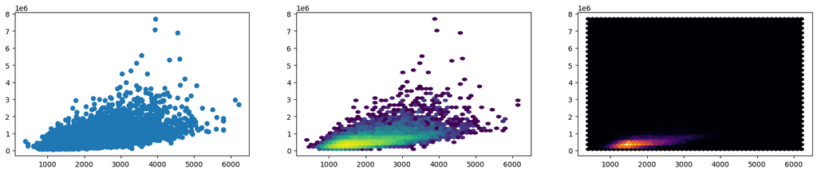

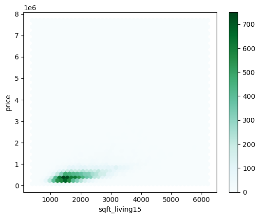

```python
plt.figure(figsize = (20, 8))

plt.subplot(2,3,1)
plt.scatter(x=house_data['sqft_living15'], y=house_data['price'])
plt.subplot(2,3,2)
plt.hexbin(x=house_data['sqft_living15'], y=house_data['price'], gridsize=50, bins='log')
plt.subplot(2,3,3)
plt.hexbin(x=[house_data['sqft_living15']], y=house_data['price'], gridsize=50, cmap='inferno')

house_data.plot.hexbin(x='sqft_living15', y='price', gridsize=45)
```

## q6

Right now we will analyze missing values and their percentage in each field.  
We will also try differrent ways of handling missing values in our dataset.

# Data preproccessing

## q1

There are numerous ways of handling missing values in a dataset.  
Beside deleting columns or filling empty cells with aggregated values such as mean, mode or median, there are also other ways such as :

1- Dropping row or columns based on a threshold value:  
It might not be a good idea to delete all columns/rows containing nan values, it would be better to delete the ones that have 'lots of' missing values and to avoid those which have 'few' missing values, such method is done by dropping nan values based on a threshold value for example thresh=5 indicates that there must be at least 5 nan values in a row/column to be dropped.

2- Dropping based on a particular subset of columns:  
In this method, we select a subset of columns that if a row has nan values in those column, then that row will be marked for dropping.

3- Drop rows or columns that are full of missing values:  
Another situation is to have a column or row that is full of missing values. Such columns or rows are useless so we can drop them.

4- Constant value filling:  
We can select a constant value to replace all nan cells with it.

5- Replacing with the previous or next value: It is possible to replace the missing values in a column with the previous or next value in that column.  
This method might come in handy when working with time-series data.

6- Fill by using another data frame:  
We can also pass another data frame to the fillna function. The values in the new data frame will be used to replace the missing values in the current data frame.

In this dataset, replacing missing values with mean for numerical data and replacement with mode for non-numerical, data would probably be the best option.

## q2

Columns 'sqft_living', 'floors', 'yr_built', 'sqft_basement' have highest number of missing values.

```python
def get_percent_NaN(col_or_row) :
    return (col_or_row.isnull().sum() / len(col_or_row)) * 100

nan_col_percent = house_data.apply(get_percent_NaN)
nan_row_percent = house_data.apply(get_percent_NaN, axis=1)
# print(nan_col_percent)
# print(nan_row_percent)

# Remove cols and rows that have lots of NaN values according to threshold
limit_remove_col, limit_remove_row = 70, 30 #percentage
cols_should_remove = list(nan_col_percent[ nan_col_percent > limit_remove_col].index)
rows_should_remove = list(nan_row_percent[ nan_row_percent > limit_remove_row].index)

house_data.drop(cols_should_remove, axis="columns", inplace=True)
house_data.drop(rows_should_remove, axis="rows", inplace=True)

# fill NaN cell with mean of col
house_data.fillna(house_data.mean(), inplace = True)

# Remove rows that have negative value
# house_data = (house_data[(house_data[house_data.columns] >= 0).all(axis=1)])

house_data.info()
regr_data_ph1 = house_data
```

```
<class 'pandas.core.frame.DataFrame'>
RangeIndex: 21613 entries, 0 to 21612
Data columns (total 27 columns):
 #   Column         Non-Null Count  Dtype
---  ------         --------------  -----
 0   Unnamed: 0.2   21613 non-null  int64
 1   Unnamed: 0.1   21613 non-null  int64
 2   Unnamed: 0     21613 non-null  int64
 3   id             21613 non-null  int64
 4   date           21613 non-null  object
 5   price          21613 non-null  float64
 6   bedrooms       21613 non-null  int64
 7   bathrooms      21613 non-null  float64
 8   sqft_living    21613 non-null  float64
 9   sqft_lot       21613 non-null  int64
```

[output cut: 19 more lines]

## q3

Standardization is a scaling technique in which the values end up being centered around the mean with a unit standard deviation.

Normalization (a.k.a min-max scaling) is a scaling technique which tries to shift and rescale values so that they end up being in range of 0 to 1.

Normalization is better to be used when we know that our data(values dataset) doesnt follow a gaussian distribution (a.k.a normal distribution).  
Standardization can be used when we know that our data follows a normal distribution.  
Now let us make a decision by analyzing our dataset.

```
array([[<Axes: title={'center': 'Unnamed: 0.2'}>,
        <Axes: title={'center': 'Unnamed: 0.1'}>,
        <Axes: title={'center': 'Unnamed: 0'}>,
        <Axes: title={'center': 'id'}>,
        <Axes: title={'center': 'price'}>],
       [<Axes: title={'center': 'bedrooms'}>,
        <Axes: title={'center': 'bathrooms'}>,
        <Axes: title={'center': 'sqft_living'}>,
        <Axes: title={'center': 'sqft_lot'}>,
        <Axes: title={'center': 'floors'}>],
       [<Axes: title={'center': 'waterfront'}>,
        <Axes: title={'center': 'view'}>,
        <Axes: title={'center': 'condition'}>,
        <Axes: title={'center': 'grade'}>,
        <Axes: title={'center': 'sqft_above'}>],
       [<Axes: title={'center': 'sqft_basement'}>,
        <Axes: title={'center': 'yr_built'}>,
        <Axes: title={'center': 'yr_renovated'}>,
        <Axes: title={'center': 'zipcode'}>,
        <Axes: title={'center': 'lat'}>],
       [<Axes: title={'center': 'long'}>,
        <Axes: title={'center': 'sqft_living15'}>,
        <Axes: title={'center': 'sqft_lot15'}>,
        <Axes: title={'center': 'house_age'}>, <Axes: >]], dtype=object)
```

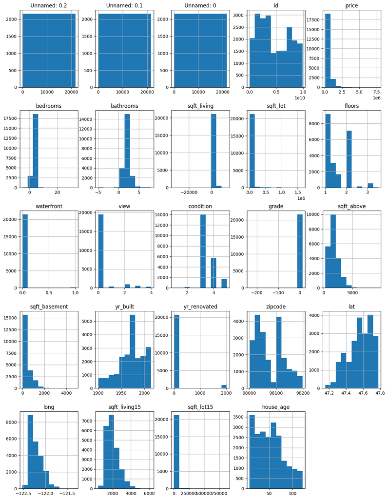

```python
fig = plt.figure(figsize = (15,20))
ax = fig.gca()
house_data.hist(ax = ax)
```

It can be observed that some of our features(columns) are close to a normal dustribution.  
Also we would like our values to be in a more specific range in order to have a good measurement for comparing data, so we choose standardization technique here so that our values reach a normal distribution and most of values get in range of (-1,1).

```python
from sklearn.preprocessing import StandardScaler, OrdinalEncoder
from pandas.api.types import is_numeric_dtype

for feature in house_data:
    if is_numeric_dtype(house_data[feature]) and feature != 'price':
        scaled_val = StandardScaler().fit(house_data[[feature]])
        house_data[feature] = scaled_val.transform(house_data[[feature]])
```

After standardization we can now see that mean of numeric column is now close to 0 and the standard deviation close to 1.

```python
for feature in house_data:
    if is_numeric_dtype(house_data[feature]):
        print(feature, '=> mean:', house_data[feature].mean(), 'std:', house_data[feature].std())
```

```
Unnamed: 0.2 => mean: 0.0 std: 1.0000231350275917
Unnamed: 0.1 => mean: 0.0 std: 1.0000231350275917
Unnamed: 0 => mean: 0.0 std: 1.0000231350275917
id => mean: 1.1440747330056672e-16 std: 1.0000231350275917
price => mean: 540182.1587933188 std: 367362.2317180084
bedrooms => mean: 2.4065020245981275e-16 std: 1.0000231350275917
bathrooms => mean: 2.2092477602868056e-16 std: 1.0000231350275917
sqft_living => mean: -3.156068228981151e-16 std: 1.0000231350275917
sqft_lot => mean: 1.0520227429937171e-17 std: 1.0000231350275914
floors => mean: 8.416181943949737e-17 std: 1.0000231350275914
waterfront => mean: -5.2601137149685855e-18 std: 1.0000231350275919
view => mean: -1.0520227429937171e-17 std: 1.0000231350275917
condition => mean: -2.5774557203346067e-16 std: 1.0000231350275917
grade => mean: 1.7884386630893189e-16 std: 1.0000231350275914
sqft_above => mean: 1.1046238801434028e-16 std: 1.0000231350275917
sqft_basement => mean: -4.2080909719748684e-17 std: 1.0000231350275917
yr_built => mean: 3.1981491387008998e-15 std: 1.0000231350275917
yr_renovated => mean: 1.3150284287421464e-18 std: 1.0000231350275919
zipcode => mean: -8.962148871852757e-14 std: 1.0000231350275914
lat => mean: -3.4322899504384386e-14 std: 1.0000231350275914
long => mean: -3.667614287761846e-14 std: 1.0000231350275914
sqft_living15 => mean: 8.153176258201307e-17 std: 1.0000231350275917
sqft_lot15 => mean: -2.893062543232722e-17 std: 1.0000231350275917
house_age => mean: 0.0 std: 1.0000231350275917
```

## q4

In order to handle categorial data and converting them to numerical values there are numerous ways.  
Generally two methods are used for handling them :

- One Hot Encoding :

In this method new columns will be added for each categorial value and a binary vector will be assigned to each row.

- Label encoding :

A number will be assigned to each categorial value (ususally usefull when dealling with data that has numerous categories).

Generally this operation must be done for features which will be effective in prediction.

Label encodeing is not a good option here since there is no particular ordering in our categories(categorial values).  
It's better to use One Hot Encoding here, we'll use ordinal encoding for 'date'column since it has lots of different values(categories).  
However since there are not so many different values in 'location' and 'style' features, we'll use One Hot Encoding for them. (In such case not so many columns would be added and not so much memory would be spent either).  
columns like 'unnamed 0.1, unnamed 0.2, unnamed(first 3 columns) are useless here (we'll talk about them in next question)

```python
from sklearn.preprocessing import OrdinalEncoder

ordinal = OrdinalEncoder()
ordinal_features = ['date']
house_data[ordinal_features] = ordinal.fit_transform(house_data[ordinal_features].astype(str)).astype(int)
```

```python
house_data = pd.get_dummies(house_data, columns = ['style', 'location'])
```

```python
house_data.head()
```

|  | Unnamed: 0.2 | Unnamed: 0.1 | Unnamed: 0 | id | date | price | bedrooms | bathrooms | sqft_living | sqft_lot | ... | sqft_lot15 | house_age | style_Cape Cod | style_Colonial | style_Contemporary | style_Ranch | style_Victorian | location_Rural | location_Suburban | location_Urban |
| --- | --- | --- | --- | --- | --- | --- | --- | --- | --- | --- | --- | --- | --- | --- | --- | --- | --- | --- | --- | --- | --- |
| 0 | -1.731971 | -1.731971 | -1.731971 | 0.886146 | 164 | 221900.0 | -0.389673 | -1.424274 | -1.016219 | -0.228321 | ... | -0.260715 | 0.544898 | 0 | 0 | 1 | 0 | 0 | 0 | 1 | 0 |
| 1 | -1.731810 | -1.731810 | -1.731810 | 0.637511 | 220 | 538000.0 | -0.389673 | 0.176897 | 0.557526 | -0.189885 | ... | -0.187868 | 0.681079 | 0 | 0 | 0 | 1 | 0 | 0 | 1 | 0 |
| 2 | -1.731650 | -1.731650 | -1.731650 | 0.365444 | 290 | 180000.0 | -1.450111 | -1.424274 | -1.480417 | -0.123298 | ... | -0.172375 | 1.293892 | 0 | 0 | 0 | 0 | 1 | 1 | 0 | 0 |
| 3 | -1.731490 | -1.731490 | -1.731490 | -0.727656 | 220 | 604000.0 | 0.670765 | 1.137599 | -0.133111 | -0.244014 | ... | -0.284522 | 0.204446 | 0 | 1 | 0 | 0 | 0 | 0 | 0 | 1 |
| 4 | -1.731330 | -1.731330 | -1.731330 | -0.912881 | 283 | 510000.0 | -0.389673 | -0.143337 | -0.450124 | -0.169653 | ... | -0.192849 | -0.544548 | 1 | 0 | 0 | 0 | 0 | 0 | 1 | 0 |

5 rows × 33 columns

## q5

If a column(feature) does not contain values important and effective for prediction, or has lots of missing values (nan) inside it, we can drop it.  
Generally features that has a very low 'information gain' can be deleted/removed from our dataset.  
It must be noted that if we do not remove these features from our dataset we might face overfitting problems in our prediction procedure.  
Now let us check our dataset once again.  
We use sklearn library to check information gain of features in our dataset.

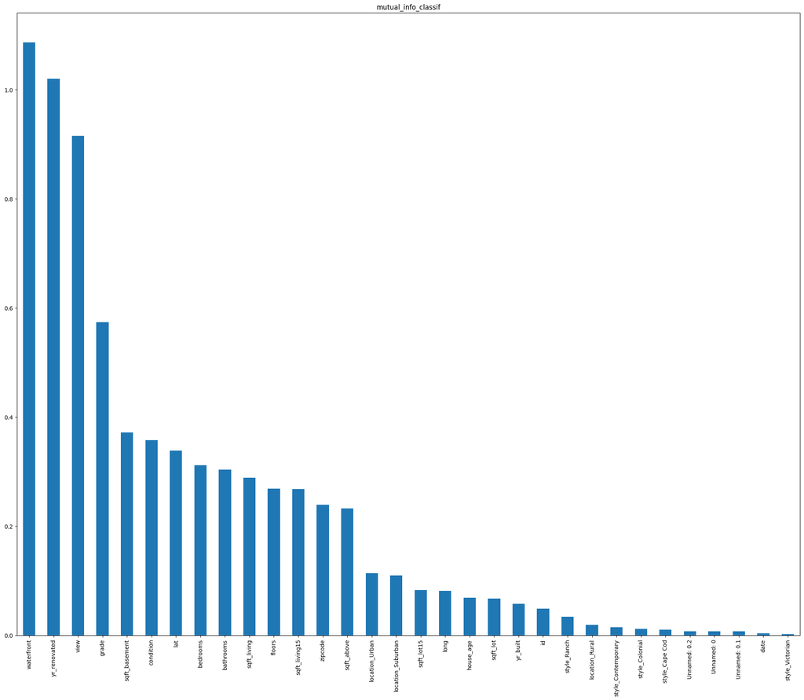

```python
from sklearn.feature_selection import mutual_info_classif

x=house_data.drop(['price'], axis=1, inplace=False)
y=house_data['price']
info = mutual_info_classif(x, y)
ig = pd.Series(info)
ig.index = x.columns
ig.sort_values(ascending = False, inplace = True)

plt.title('mutual_info_classif')
ig.plot.bar(figsize=(25,20))
plt.show()
```

```python
house_data.head()
```

|  | Unnamed: 0.2 | Unnamed: 0.1 | Unnamed: 0 | id | date | price | bedrooms | bathrooms | sqft_living | sqft_lot | ... | sqft_lot15 | house_age | style_Cape Cod | style_Colonial | style_Contemporary | style_Ranch | style_Victorian | location_Rural | location_Suburban | location_Urban |
| --- | --- | --- | --- | --- | --- | --- | --- | --- | --- | --- | --- | --- | --- | --- | --- | --- | --- | --- | --- | --- | --- |
| 0 | -1.731971 | -1.731971 | -1.731971 | 0.886146 | 164 | 221900.0 | -0.389673 | -1.424274 | -1.016219 | -0.228321 | ... | -0.260715 | 0.544898 | 0 | 0 | 1 | 0 | 0 | 0 | 1 | 0 |
| 1 | -1.731810 | -1.731810 | -1.731810 | 0.637511 | 220 | 538000.0 | -0.389673 | 0.176897 | 0.557526 | -0.189885 | ... | -0.187868 | 0.681079 | 0 | 0 | 0 | 1 | 0 | 0 | 1 | 0 |
| 2 | -1.731650 | -1.731650 | -1.731650 | 0.365444 | 290 | 180000.0 | -1.450111 | -1.424274 | -1.480417 | -0.123298 | ... | -0.172375 | 1.293892 | 0 | 0 | 0 | 0 | 1 | 1 | 0 | 0 |
| 3 | -1.731490 | -1.731490 | -1.731490 | -0.727656 | 220 | 604000.0 | 0.670765 | 1.137599 | -0.133111 | -0.244014 | ... | -0.284522 | 0.204446 | 0 | 1 | 0 | 0 | 0 | 0 | 0 | 1 |
| 4 | -1.731330 | -1.731330 | -1.731330 | -0.912881 | 283 | 510000.0 | -0.389673 | -0.143337 | -0.450124 | -0.169653 | ... | -0.192849 | -0.544548 | 1 | 0 | 0 | 0 | 0 | 0 | 1 | 0 |

5 rows × 33 columns

```python
house_data.drop(['Unnamed: 0.2','Unnamed: 0.1','Unnamed: 0','date'], axis=1, inplace=True)
```

```python
house_data.head()
```

|  | id | price | bedrooms | bathrooms | sqft_living | sqft_lot | floors | waterfront | view | condition | ... | sqft_lot15 | house_age | style_Cape Cod | style_Colonial | style_Contemporary | style_Ranch | style_Victorian | location_Rural | location_Suburban | location_Urban |
| --- | --- | --- | --- | --- | --- | --- | --- | --- | --- | --- | --- | --- | --- | --- | --- | --- | --- | --- | --- | --- | --- |
| 0 | 0.886146 | 221900.0 | -0.389673 | -1.424274 | -1.016219 | -0.228321 | -0.988457 | -0.087173 | -0.305759 | -0.629187 | ... | -0.260715 | 0.544898 | 0 | 0 | 1 | 0 | 0 | 0 | 1 | 0 |
| 1 | 0.637511 | 538000.0 | -0.389673 | 0.176897 | 0.557526 | -0.189885 | 0.000000 | -0.087173 | -0.305759 | -0.629187 | ... | -0.187868 | 0.681079 | 0 | 0 | 0 | 1 | 0 | 0 | 1 | 0 |
| 2 | 0.365444 | 180000.0 | -1.450111 | -1.424274 | -1.480417 | -0.123298 | -0.988457 | -0.087173 | -0.305759 | -0.629187 | ... | -0.172375 | 1.293892 | 0 | 0 | 0 | 0 | 1 | 1 | 0 | 0 |
| 3 | -0.727656 | 604000.0 | 0.670765 | 1.137599 | -0.133111 | -0.244014 | -0.988457 | -0.087173 | -0.305759 | 2.444294 | ... | -0.284522 | 0.204446 | 0 | 1 | 0 | 0 | 0 | 0 | 0 | 1 |
| 4 | -0.912881 | 510000.0 | -0.389673 | -0.143337 | -0.450124 | -0.169653 | -0.988457 | -0.087173 | -0.305759 | -0.629187 | ... | -0.192849 | -0.544548 | 1 | 0 | 0 | 0 | 0 | 0 | 1 | 0 |

5 rows × 29 columns

## q6

One of the common ways of splitting data to test/train sets is to take first X% of data for train and the rest for the test set.  
However it must be noted that the dataset must actually be shuffled before splliting and the ratio of unique 'price' values to all data in both test and train must be equal(or very close).  
The ratio of each output(reault of prediction which is price here) in test and train must be equal too, and our train model must not face a bias in prediction and must not tend to a specific value (output).  
Our test set on the other hand should also have a good prediction.  
In order to split test/train like said we can use 'train_test_split' in 'Sklearn' library.  
Usually a 70/30 or 80/20 ratio for train/test split is good. (we use 75/25 here)

```python
from sklearn.model_selection import train_test_split
data_val, price_label = house_data.drop(['price'], axis=1, inplace=False) , house_data['price']
data_train, data_test, label_train, label_test = train_test_split(data_val, price_label, random_state=42, test_size=0.25) #the answer to the ultimate question of life, the universe, and everything. :))
print(len(data_test),  len(data_train))
print(len(label_test), len(label_train))
```

```
5404 16209
5404 16209
```

## q7

This set is usually used for setting hyper parameters.  
Actually, before evaluating and running the model on the test data, we adjust the hyper parameters of our model using validation data.

# Phase 1

# Linear Regression

Main form of simple linear regression function: $$f(x) = \alpha x + \beta$$

- step 1: Compute RSS of the training data

$$ RSS = \Sigma (y_i - (\hat{\beta} + \hat{\alpha} * x_i) )^2 $$

- step 2: Compute the derivatives of the RSS function in term of $\underline{\alpha}$ and $\underline{\beta}$, and set them equal to 0 to find the desired parameters

$$ \frac{\partial RSS}{\partial \beta} = \Sigma (-f(x_i) + \hat{\beta} + \hat{\alpha} * x_i) = 0$$$$ \to \hat{\beta} = \hat{y} - \hat{\alpha} \hat{x} \to (1)$$$$ \frac{\partial RSS}{\partial \alpha} = \Sigma (-2 x_i y_i + 2 \hat{\beta} x_i + 2\hat{\alpha} x_i ^ 2) = 0 \to (2)$$$$ (1) , (2) \to \hat{\alpha} = \frac{\Sigma{(x_i - \hat{x})(y_i - \hat{y})}}{\Sigma{(x_i - \hat{x})^2}} $$

$$ \hat{\beta} = \hat{y} - \hat{\alpha} \hat{x}$$

Based on the formula above, complete this function to compute the parameters of a simple linear regression

```python
def simple_linear_regression(input_feature, output):
    # TO DO:

    # compute the sum of input_feature and output
    sum_input = input_feature.sum()
    sum_output = output.sum()
    num_data = len(output)

    # compute the product of the output and the input_feature and its sum
    product_of_inp_out = input_feature * output
    sum_product = product_of_inp_out.sum()

    # compute the squared value of the input_feature and its sum
    input_squared = input_feature*input_feature
    squared_sum  = input_squared.sum()

    # use the formula for the slope
    numerator = sum_product - ((float(1)/num_data) * (sum_input*sum_output))
    denominator = squared_sum - ((float(1)/num_data) * (sum_input*sum_input))
    slope = numerator/denominator

    # use the formula for the intercept
    intercept = output.mean()-(slope*input_feature.mean())

    return (intercept, slope)
```

Now complete this function to predict the value of given data based on the calculated intercept and slope

```python
def get_regression_predictions(input_feature, intercept, slope):
    # TO DO:
    # calculate the predicted values:
    predicted_values= slope*input_feature + intercept
    return (predicted_values)
```

Now that we have a model and can make predictions let's evaluate our model using Root Mean Square Error (RSME). RMSE is the square root of the mean of the squared differences between the residuals and the residuals is just a fancy word for the difference between the predicted output and the true output.

Complete the following function to compute the RSME of a simple linear regression model given the input_feature, output, intercept and slope:

```python
def get_root_mean_square_error(predicted_values , output):
    # TO DO:

    # Compute the residuals (since we are squaring it doesn't matter which order you subtract)
    residual = output - (predicted_values)

    # square the residuals and add them up
    RSS = residual * residual
#     print(RSS.sum)
    # find the mean of the above phrase
    mean = RSS.sum()/len(RSS)
    # calculate the root
    RMSE = math.sqrt(mean)
    return(RMSE)
```

AS you might guessed, the RMSE has no bound and it is not easy to find out the percentage of fitting the model into data with it. instead, we use R2 score. The R2 score is calculated by comparing the sum of the squared differences between the actual and predicted values of the dependent variable to the total sum of squared differences between the actual and mean values of the dependent variable. Matematically, the R2 score formula is shown as follows:

$$R^2 = 1 - \frac{SSres}{SStot} = 1 - \frac{\sum_{i=1}^{n} (y_{i,true} - y_{i,pred})^2}{\sum_{i=1}^{n} (y_{i,true} - \bar{y}_{true})^2} $$

In this step, complete the following function to calculate the R2 score of a given input_feature, output, intercept, and slope:

```python
def get_r2_score(predicted_values, output):
    # TO DO:

    # then compute the residuals (since we are squaring it doesn't matter which order you subtract)
    residual = output - (predicted_values)

    # square the residuals and add them up -> SSres
    SSres = residual * residual
    SSres = SSres.sum()

    # compute the SStot
    err_mean = sum(output)/len(output)
    err = output
    err = np.array([x - err_mean for x in err])

    SStotL= err * err
    SStot = SStotL.sum()

    # compute the R2 score value
    R2_score = 1-(SSres/SStot)
    return(R2_score)
```

Now calculate the fitness of the model and explain the outputs

```python
# TO DO:
## test for train data
designated_feature_list = ['sqft_living' , 'yr_built' , 'grade' , 'zipcode']

for feature in designated_feature_list:
    print('*** Feature:', feature)
    intercept, slope = simple_linear_regression(regr_data_ph1[feature], regr_data_ph1['price'])
    predicted        = get_regression_predictions(regr_data_ph1[feature], intercept, slope)
    RSME             = get_root_mean_square_error(predicted, regr_data_ph1['price'])
    R2               = get_r2_score(predicted, regr_data_ph1['price'])
    print("RSME:", RSME)
    print("R2 Score:", R2)
    print(' ')
```

```
*** Feature: sqft_living
RSME: 285321.0718932141
R2 Score: 0.3967479881303173

*** Feature: yr_built
RSME: 366890.6155823228
R2 Score: 0.002519780978244235

*** Feature: grade
RSME: 338384.9116288185
R2 Score: 0.15149761982248722

*** Feature: zipcode
RSME: 366834.13721633365
R2 Score: 0.0028268573348362303
```

# Phase 2

# classification

## price level

Before implementing classification we must create 'price_level' feature in our data set.  
This will be done for both test and train datasets.

```python
import copy
train_label_median = label_train.median()
test_label_median = label_test.median()
print(train_label_median, test_label_median)

print(len(label_train))
label_train_lv = copy.deepcopy(label_train)
label_test_lv  = copy.deepcopy(label_test)

for i, v in label_train.items() :
    if(v > train_label_median):
        label_train_lv[i] = "HIGH"
    else:
        label_train_lv[i] = "LOW"

for i, v in label_test.items() :
    if(v > test_label_median):
        label_test_lv[i] = "HIGH"
    else:
        label_test_lv[i] = "LOW"

print(label_train_lv)
print(label_train)
print(label_test_lv)
print(label_test)
```

```
450000.0 450650.0
16209
5945      LOW
8423      LOW
13488     LOW
20731     LOW
2358      LOW
         ...
11964     LOW
21575     LOW
5390     HIGH
860       LOW
15795     LOW
Name: price, Length: 16209, dtype: object
5945     268643.0
```

[output cut: 35 more lines]

## q1 , q2

After the execution of each algorithm, the confusion matrix is drawn and the necessary calculations are also displayed. In some algorithms, in addition to manually testing the model with different parameter values, the GridSearchCV function has also been used.

## q3

### Underfitting

Undefitting happens when we have not trained our model well for reasons such as bad hyperparameter values or low train data.  
If this happens, our model has little accuracy and cannot make good predictions.  
In other words, underfitting happenes when our model does not even predict the training data correctly, which in this, our model is high bias.

### Overfitting

Overfitting happens if we pay too much attention to details and even model the noise in the data.  
In this case, the accuracy of the model is very high for predicting the train data, but it is low for the test data.  
In fact, there is a gap between the accuracy of the training and the test data, which in this our models are high variance.

## q4

In the models implemented below, this(overfitting/underfitting) may happen due to the different values of the parameters and the way the data is divided(splitted).  
For each algorithm, the graph and various accuracy measurements are displayed, and for each algorithm, calculations have been made separately, which can be seen below.  
We try to reduce the possibility of overfitting by removing the columns that have very low information gain and changing the various parameters of the model as well as the pre-processing that we did in the previous steps.

# K-Nearest-Neighbours

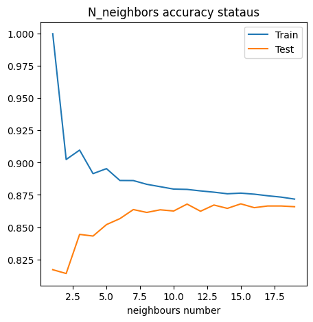

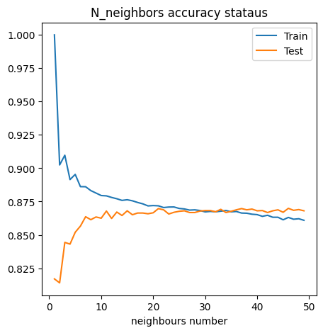

```python
from sklearn.metrics import classification_report, confusion_matrix, ConfusionMatrixDisplay, accuracy_score
from sklearn.neighbors import KNeighborsClassifier
from sklearn.model_selection import GridSearchCV

def plot_KNN_model(neighbour_range_max) :
    neighbours = range(1,neighbour_range_max)
    test_accuracy  = []
    train_accuracy = []

    for i in neighbours:
        knn = KNeighborsClassifier(n_neighbors=i)
        knn.fit(data_train, label_train_lv)

        train_prediction = knn.predict(data_train)
        train_accuracy.append(accuracy_score(label_train_lv, train_prediction))

        test_prediction = knn.predict(data_test)
        test_accuracy.append(accuracy_score(label_test_lv, test_prediction))

    plt.figure(figsize=(5, 5))
    plt.plot(neighbours, train_accuracy, label='Train')
    plt.plot(neighbours, test_accuracy,  label='Test')
    plt.legend()
    plt.xlabel("neighbours number")
    plt.title('N_neighbors accuracy stataus')
    plt.show()

plot_KNN_model(20)
plot_KNN_model(50)
```

By looking at the plot we can see that the difference between accuracy in train and test for low neighbours (e.g, 1) is very high (high accuracy in train and low one in test).  
This indicates overfitting, however if we look at plot again values between 15 to 20 would be much better for K in knn, so we set as a value in this range (18 here)  
Note that a value between 20 to 30 would be also good here, but we choose 18 here.

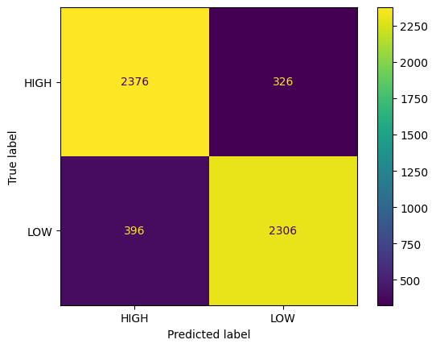

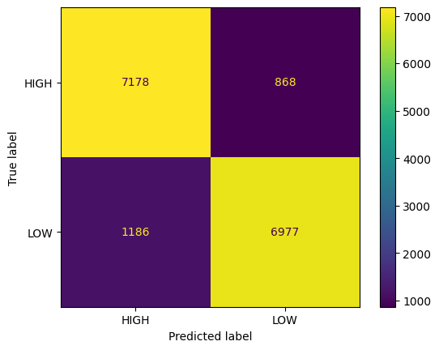

```python
knn = KNeighborsClassifier(n_neighbors=18)
knn.fit(data_train, label_train_lv)

train_prediction = knn.predict(data_train)
train_accuracy.append(accuracy_score(label_train_lv, train_prediction))

test_prediction = knn.predict(data_test)
test_accuracy.append(accuracy_score(label_test_lv, test_prediction))

cnf_matrix = confusion_matrix(label_test_lv, test_prediction, labels=knn.classes_)
display = ConfusionMatrixDisplay(confusion_matrix=cnf_matrix, display_labels=knn.classes_)
display.plot()
plt.show()

cnf_matrix_2 = confusion_matrix(label_train_lv, train_prediction, labels=knn.classes_)
display = ConfusionMatrixDisplay(confusion_matrix=cnf_matrix_2, display_labels=knn.classes_)
display.plot()
plt.show()
```

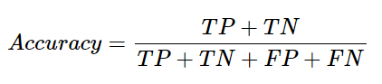

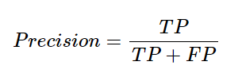

now we'll calculate them in code too:

```python
from sklearn.metrics import recall_score, precision_score
accuracy_test  = accuracy_score(label_test_lv, test_prediction)
precision_test = precision_score(label_test_lv, test_prediction, pos_label='LOW')
recall_test    = recall_score(label_test_lv, test_prediction, pos_label='LOW')

accuracy_train  =  accuracy_score(label_train_lv, train_prediction)
precision_train =  precision_score(label_train_lv, train_prediction, pos_label='LOW')
recall_train    =  recall_score(label_train_lv, train_prediction, pos_label='LOW')
print('for training data : ')
print('accuracy:', accuracy_train, 'precision:', precision_train, 'recall:', recall_train)
print('for testing data : ')
print('accuracy:', accuracy_test, 'precision:', precision_test, 'recall:', recall_test)
```

```
for training data :
accuracy: 0.8732802763896601 precision: 0.8893562778840025 recall: 0.8547102780840378
for testing data :
accuracy: 0.8663952627683198 precision: 0.8761398176291794 recall: 0.8534418948926721
```

Now the prediction scores the train/test data are close to each other.

# Decision Trees

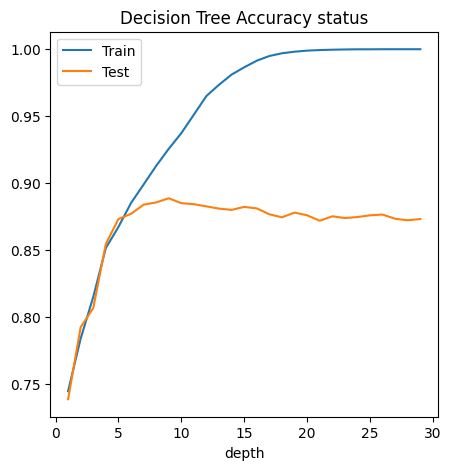

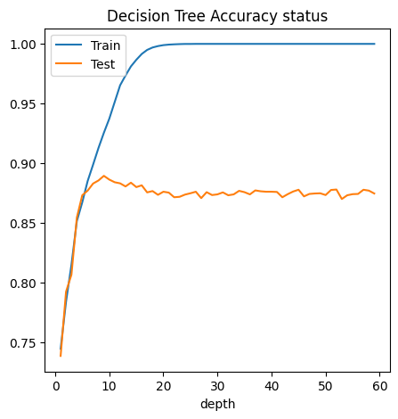

```python
from sklearn.tree import DecisionTreeClassifier

def plot_decision_tree_model(depth_range_max) :
    depths = range(1, depth_range_max)
    test_accuracy  = []
    train_accuracy = []

    for depth in depths:
        decision_tree = DecisionTreeClassifier(max_depth=depth)
        decision_tree.fit(data_train, label_train_lv)

        train_prediction = decision_tree.predict(data_train)
        train_accuracy.append(accuracy_score(label_train_lv, train_prediction))

        test_prediction = decision_tree.predict(data_test)
        test_accuracy.append(accuracy_score(label_test_lv, test_prediction))

    plt.figure(figsize=(5, 5))
    plt.plot(depths, train_accuracy, label='Train')
    plt.plot(depths, test_accuracy, label='Test')
    plt.legend()
    plt.xlabel('depth')
    plt.title('Decision Tree Accuracy status')
    plt.show()

plot_decision_tree_model(30)
plot_decision_tree_model(60)
```

As we can see, if our max_depth goes more than 5 we'll face overfitting, so in order to avoid it and also to avoid underfitting, we'll set our max_depth to 5.  
Now lets check other factors in the classifier and analyze them.

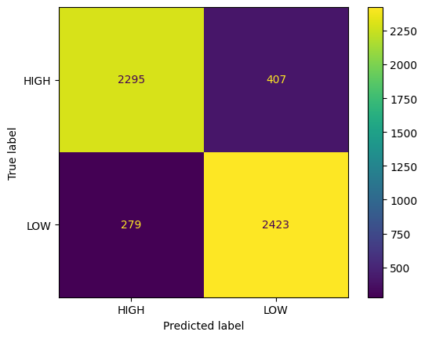

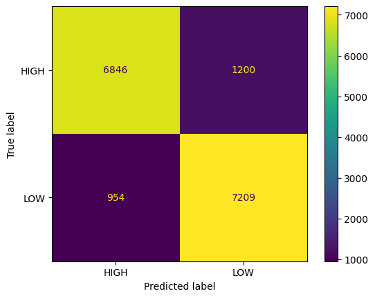

```python
decision_tree = DecisionTreeClassifier(max_depth=5)
decision_tree.fit(data_train, label_train_lv)

train_prediction = decision_tree.predict(data_train)
train_accuracy.append(accuracy_score(label_train_lv, train_prediction))

test_prediction = decision_tree.predict(data_test)
test_accuracy.append(accuracy_score(label_test_lv, test_prediction))

cnf_matrix_3 = confusion_matrix(label_test_lv, test_prediction, labels=decision_tree.classes_)
display = ConfusionMatrixDisplay(confusion_matrix=cnf_matrix_3, display_labels=decision_tree.classes_)
display.plot()
plt.show()

cnf_matrix_4 = confusion_matrix(label_train_lv, train_prediction, labels=decision_tree.classes_)
display = ConfusionMatrixDisplay(confusion_matrix=cnf_matrix_4, display_labels=decision_tree.classes_)
display.plot()
plt.show()
```

```python
accuracy_test   =  accuracy_score(label_test_lv, test_prediction)
precision_test  =  precision_score(label_test_lv, test_prediction, pos_label='LOW')
recall_test     =  recall_score(label_test_lv, test_prediction, pos_label='LOW')

accuracy_train  =  accuracy_score(label_train_lv, train_prediction)
precision_train =  precision_score(label_train_lv, train_prediction, pos_label='LOW')
recall_train    =  recall_score(label_train_lv, train_prediction, pos_label='LOW')
print('for training data : ')
print('accuracy:', accuracy_train, 'precision:', precision_train, 'recall:', recall_train)
print('for testing data : ')
print('accuracy:', accuracy_test, 'precision:', precision_test, 'recall:', recall_test)
```

```
for training data :
accuracy: 0.8671108643346289 precision: 0.8572957545486978 recall: 0.8831312017640573
for testing data :
accuracy: 0.8730569948186528 precision: 0.8561837455830389 recall: 0.8967431532198371
```

## min_samples_leaf

We now set values for 'min_samples_leaf' attribute in decision tree classifier.

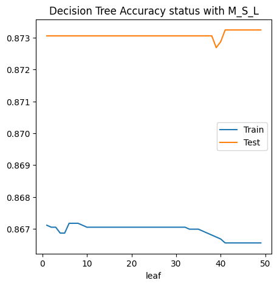

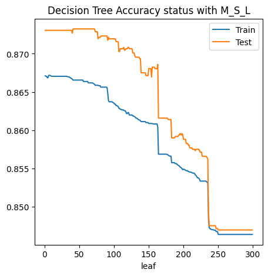

```python
def plot_decision_tree_model_min_leaf(depth_range_max) :
    leaves = range(1, depth_range_max)
    test_accuracy  = []
    train_accuracy = []

    for leaf in leaves:
        decision_tree = DecisionTreeClassifier(max_depth=5, min_samples_leaf=leaf)
        decision_tree.fit(data_train, label_train_lv)

        train_prediction = decision_tree.predict(data_train)
        train_accuracy.append(accuracy_score(label_train_lv, train_prediction))

        test_prediction = decision_tree.predict(data_test)
        test_accuracy.append(accuracy_score(label_test_lv, test_prediction))

    plt.figure(figsize=(5, 5))
    plt.plot(leaves, train_accuracy, label='Train')
    plt.plot(leaves, test_accuracy, label='Test')
    plt.legend()
    plt.xlabel('leaf')
    plt.title('Decision Tree Accuracy status with M_S_L') #M_S_L => mean_sample_leaf
    plt.show()

plot_decision_tree_model_min_leaf(50)
plot_decision_tree_model_min_leaf(300)
```

In order to avoid underfitting/overfitting we set mean_samples_leaf to 20 (between 10 to 30 is ok in this case).  
The more we increase min_samples_leaf the less accuracy we get!  
Now lets check the score measurements.

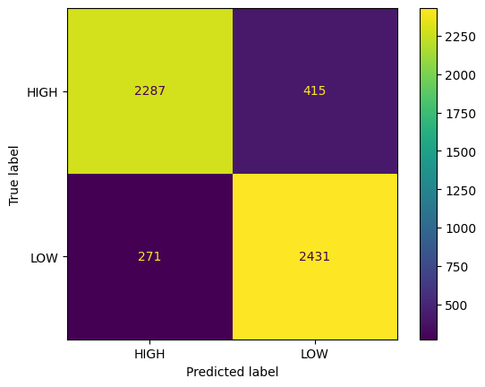

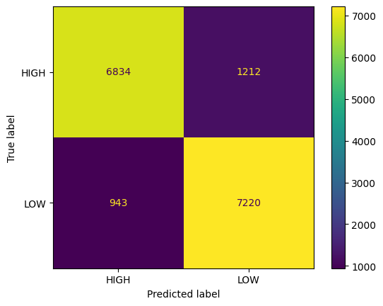

```python
decision_tree = DecisionTreeClassifier(max_depth=5, min_samples_leaf=20)
decision_tree.fit(data_train, label_train_lv)

train_prediction = decision_tree.predict(data_train)
train_accuracy.append(accuracy_score(label_train_lv, train_prediction))

test_prediction = decision_tree.predict(data_test)
test_accuracy.append(accuracy_score(label_test_lv, test_prediction))

cnf_matrix_5 = confusion_matrix(label_test_lv, test_prediction, labels=decision_tree.classes_)
display = ConfusionMatrixDisplay(confusion_matrix=cnf_matrix_5, display_labels=decision_tree.classes_)
display.plot()
plt.show()

cnf_matrix_6 = confusion_matrix(label_train_lv, train_prediction, labels=decision_tree.classes_)
display = ConfusionMatrixDisplay(confusion_matrix=cnf_matrix_6, display_labels=decision_tree.classes_)
display.plot()
plt.show()
```

```python
accuracy_test   =  accuracy_score(label_test_lv, test_prediction)
precision_test  =  precision_score(label_test_lv, test_prediction, pos_label='LOW')
recall_test     =  recall_score(label_test_lv, test_prediction, pos_label='LOW')

accuracy_train  =  accuracy_score(label_train_lv, train_prediction)
precision_train =  precision_score(label_train_lv, train_prediction, pos_label='LOW')
recall_train    =  recall_score(label_train_lv, train_prediction, pos_label='LOW')
print('for training data : ')
print('accuracy:', accuracy_train, 'precision:', precision_train, 'recall:', recall_train)
print('for testing data : ')
print('accuracy:', accuracy_test, 'precision:', precision_test, 'recall:', recall_test)
```

```
for training data :
accuracy: 0.8670491702140786 precision: 0.8562618595825426 recall: 0.8844787455592307
for testing data :
accuracy: 0.8730569948186528 precision: 0.8541813070976809 recall: 0.8997039230199851
```

Lets use gridSearchCV to find optimal value of model paramters.

## GridSearchCV

```python
parameter_grid_tree = {
              'max_depth': [1, 2, 3, 4, 5, 10, 17, 18, 20, 22, 24, 26],
              'min_samples_split': [2, 3, 4],
              'min_samples_leaf': [10, 20, 24, 25, 26, 38, 39, 40, 41, 42, 100, 150, 240, 280, 1000]
             }
GSCV_tree = GridSearchCV(decision_tree, parameter_grid_tree,n_jobs = -1, verbose = 0, scoring = 'accuracy', cv = 5)
GSCV_tree.fit(data_train, label_train_lv)

print(GSCV_tree.best_params_)
print(GSCV_tree.score(data_train, label_train_lv))
print(GSCV_tree.score(data_test , label_test_lv))
```

```
{'max_depth': 18, 'min_samples_leaf': 20, 'min_samples_split': 3}
0.9109753840459004
0.8893412287194671
```

The above result shows the max accuracy we can get by changing hyperparameters and the value of those hyperparameters

# Logistic Regression

[output not shown]

[output cut: 161 more lines]

[output not shown]

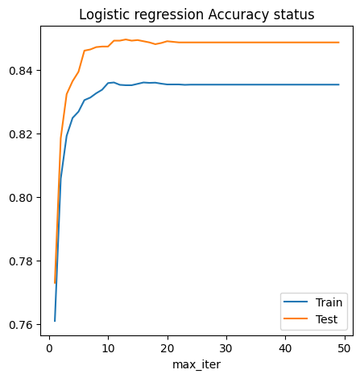

```python
from sklearn.linear_model import LogisticRegression

def plot_logistic_regression_model(iters_range_max) :
    iters = range(1, iters_range_max)
    test_accuracy  = []
    train_accuracy = []

    for i in iters:
        log_regression = LogisticRegression(max_iter=i, random_state=4)
        log_regression.fit(data_train, label_train_lv)

        train_prediction = log_regression.predict(data_train)
        train_accuracy.append(accuracy_score(label_train_lv, train_prediction))

        test_prediction = log_regression.predict(data_test)
        test_accuracy.append(accuracy_score(label_test_lv, test_prediction))

    plt.figure(figsize=(5, 5))
    plt.plot(iters, train_accuracy, label='Train')
    plt.plot(iters, test_accuracy,  label='Test')
    plt.legend()
    plt.xlabel('max_iter')
    plt.title('Logistic regression Accuracy status') #M_S_L => mean_sample_leaf
    plt.show()

plot_logistic_regression_model(50)
```

The accuracies of test/train sets are close to each other and it can be said that there is almost no overfitting in most values ranges.  
Now in order to find optimal value of parameters we use searchGridCV.  
But before this we calculate evaluation scores considering max_iter=30

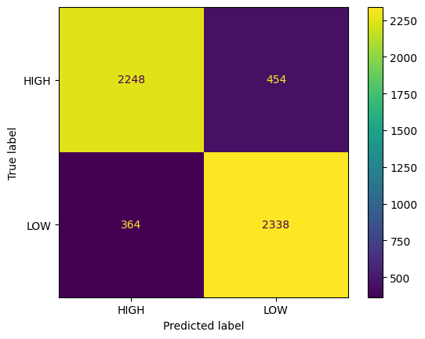

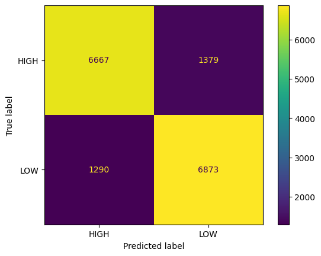

```python
log_regression = LogisticRegression(max_iter=30, random_state=4)
log_regression.fit(data_train, label_train_lv)

train_prediction = log_regression.predict(data_train)
train_accuracy.append(accuracy_score(label_train_lv, train_prediction))

test_prediction = log_regression.predict(data_test)
test_accuracy.append(accuracy_score(label_test_lv, test_prediction))

cnf_matrix_7 = confusion_matrix(label_test_lv, test_prediction, labels=log_regression.classes_)
display = ConfusionMatrixDisplay(confusion_matrix=cnf_matrix_7, display_labels=log_regression.classes_)
display.plot()
plt.show()

cnf_matrix_8 = confusion_matrix(label_train_lv, train_prediction, labels=log_regression.classes_)
display = ConfusionMatrixDisplay(confusion_matrix=cnf_matrix_8, display_labels=log_regression.classes_)
display.plot()
plt.show()
```

```python
accuracy_test   =  accuracy_score(label_test_lv, test_prediction)
precision_test  =  precision_score(label_test_lv, test_prediction, pos_label='LOW')
recall_test     =  recall_score(label_test_lv, test_prediction, pos_label='LOW')

accuracy_train  =  accuracy_score(label_train_lv, train_prediction)
precision_train =  precision_score(label_train_lv, train_prediction, pos_label='LOW')
recall_train    =  recall_score(label_train_lv, train_prediction, pos_label='LOW')

print('for training data : ')
print('accuracy:', accuracy_train, 'precision:', precision_train, 'recall:', recall_train)
print('for testing data : ')
print('accuracy:', accuracy_test, 'precision:', precision_test, 'recall:', recall_test)
```

```
for training data :
accuracy: 0.8353383922512184 precision: 0.8328889966068832 recall: 0.8419698640205807
for testing data :
accuracy: 0.8486306439674315 precision: 0.8373925501432665 recall: 0.8652849740932642
```

### searchGridCV

```python
param_grid = {'penalty':('l1','l2', "elasticnet"), #Specify the norm of the penalty:
             'tol':(0.0001, 0.00001, 0.00005), #Tolerance for stopping criteria default= 1e-4
             'C':(0.01, 0.1, 0.5, 1, 1.3, 1.5, 1.8, 2, 3), #Inverse of regularization strength; smaller values specify stronger regularization.
#              'solver':("lbfgs", "liblinear", "newton-cg", "newton-cholesky", "sag", "saga"), #takes so much time !
              'max_iter':(5, 10, 30, 50, 100, 150, 200, 250)
             }
log_classifier = LogisticRegression()
gs_log_reg = GridSearchCV(log_classifier, param_grid,n_jobs = -1, verbose = 0, scoring = 'accuracy', cv = 5)
gs_log_reg.fit(data_train, label_train_lv)
print(gs_log_reg.best_params_)
print(gs_log_reg.score(data_train, label_train_lv))
print(gs_log_reg.score(data_test, label_test_lv))
```

[output not shown]

[output cut: 83 more lines]

[output not shown]

```
{'C': 2, 'max_iter': 30, 'penalty': 'l2', 'tol': 0.0001}
0.8354000863717688
0.8486306439674315
```

# Ensemble Learning

## q1

- max_depth :

Specifies the maximum height of each tree in the forest.

- n_estimators :

Specifies the number of trees in the forest.

- leaf_samples_min :

Specifies the minimum amount of spliting. For example, if the value of this variable is equal to 10, when the splitting of a vertex reaches less than 10, the work will continue.

- verbose :

Controls the verbosity when fitting and predicting. (default=0)

- max_features: {“sqrt”, “log2”, None}, int or float, default=”sqrt”

The number of features to consider when looking for the best split

- bootstrapbool, default=True

Whether bootstrap samples are used when building trees. If False, the whole dataset is used to build each tree.

We will see the effects of changing these hyperparameters in the coming sections.